# Building best OLS model for students’ life satisfaction prediction

Data Analysis 2020

Yulia Pankova

2022-02-18

**Research task:** What social factors explain students’ life satisfaction?

# Variables

```r
library(foreign)
library(dplyr)
library(sjPlot)
library(kableExtra)
library(sjPlot)
library(sjmisc)
library(ggplot2)

fulldata <- read.spss("hbsc.sav", to.data.frame = T)
data <- fulldata %>% select(AGECAT, sex, famhelp, famtalk, lifesat)
names(data) <- c("age", "sex", "famhelp", "famtalk", "lifesat")

data$age <- as.numeric(as.character(data$age))

levels(data$famhelp) <- c("1","2", "3", "4", "5", "6", "7")
data$famhelp <- as.numeric(as.character(data$famhelp))

levels(data$famtalk) <- c("1","2", "3", "4", "5", "6", "7")
data$famtalk <- as.numeric(as.character(data$famtalk))

levels(data$lifesat) <- c("0", "1","2", "3", "4", "5", "6", "7", "8", "9", "10")
data$lifesat <- as.numeric(as.character(data$lifesat))

data = na.omit(data)

Variable <- names(data)[c(5,1:4)]
Type <- c("Dependent", "Control", "Control", "Independent", "Independent")
Description <- c("Respondent's life satisfaction", "Respondent's age category", "Respondent's sex","Does respondent's family really tries to help him",  "Can repsondent talk about his problems with his family")
Answers <- c("0 - The worst possible, ..., 10 - The best possible", "11, 13, 15", "Boy, Girl", "1 - Very strongly disagree, ..., 7 - Very strongly agree", "1 - Very strongly disagree, ..., 7 - Very strongly agree")

descr <- data.frame(Variable, Type, Description, Answers)

descr %>% kable() %>% kable_classic_2("hover", html_font = "Cambria") %>%
  column_spec(1, bold = T) %>%
  column_spec(4, italic = T)
```

| Variable | Type | Description | Answers |
| --- | --- | --- | --- |
| lifesat | Dependent | Respondent’s life satisfaction | 0 - The worst possible, …, 10 - The best possible |
| age | Control | Respondent’s age category | 11, 13, 15 |
| sex | Control | Respondent’s sex | Boy, Girl |
| famhelp | Independent | Does respondent’s family really tries to help him | 1 - Very strongly disagree, …, 7 - Very strongly agree |
| famtalk | Independent | Can repsondent talk about his problems with his family | 1 - Very strongly disagree, …, 7 - Very strongly agree |

Besides the predefined dependent variable “lifesat” (life satisfaction), I’ll use respondent’s evaluation of his family’s help and evaluation of his opportunity to talk to them to test out the relationship between level of satisfaction with life and an interplay with family. Age and sex are picked to be control variables.

Both depedent and independent variables were measured with Likert scale, thus transformed to numeric values from 0 to 10 and from 1 to 7 correspondingly. I’ve also deleted missing values (they were less than 5% of the dataset), because creating polynomial effect is impossible having them.

# Models

## 1. Base model

This multiple regression includes both dependent and control variables, predicting a life satisfaction.

```r
m1 = lm(lifesat ~ age + sex + famhelp + famtalk, data = data)
tab_model(m1, title = "Model 1. Formula: lifesat ~ age + sex + famhelp + famtalk.")
```

Model 1. Formula: lifesat ~ age + sex + famhelp + famtalk.

|  | lifesat |  |  |
| --- | --- | --- | --- |
| Predictors | Estimates | CI | p |
| (Intercept) | 7.21 | 7.00 – 7.42 | **<0.001** |
| age | -0.13 | -0.15 – -0.12 | **<0.001** |
| sex [Girl] | -0.32 | -0.36 – -0.27 | **<0.001** |
| famhelp | 0.11 | 0.09 – 0.13 | **<0.001** |
| famtalk | 0.29 | 0.27 – 0.31 | **<0.001** |
| Observations | 24855 |  |  |
| R<sup>2</sup> / R<sup>2</sup> adjusted | 0.150 / 0.150 |  |  |

Proceeding to the predictors explanation:

- with every rise by 1 point in age, level of life satisfaction falls by 0.13 points;
- Girls are less happy than boys by 0.32 points;
- with every rise by 1 point in estimating the family’s willingness to help, life satisfaction evaluation rises by 0.11 points;
- with every rise by 1 point in estimating the family’s talking atmosphere, life satisfaction evaluation rises by 0.29 points.

## 2. Model with an interaction effect

I’ve decided to add interaction effect between sex and famtalk variables, suggesting that children of different sexes treat amount of taking to family differently.

```r
m2 = lm(lifesat ~ age + famhelp + famtalk * sex, data = data)
tab_model(m2, title = "Model 2. Formula: lifesat ~ age + famhelp + famtalk * sex.")
```

Model 2. Formula: lifesat ~ age + famhelp + famtalk * sex.

|  | lifesat |  |  |
| --- | --- | --- | --- |
| Predictors | Estimates | CI | p |
| (Intercept) | 7.59 | 7.37 – 7.81 | **<0.001** |
| age | -0.13 | -0.15 – -0.12 | **<0.001** |
| famhelp | 0.11 | 0.09 – 0.13 | **<0.001** |
| famtalk | 0.22 | 0.20 – 0.24 | **<0.001** |
| sex [Girl] | -1.07 | -1.22 – -0.93 | **<0.001** |
| famtalk * sex [Girl] | 0.14 | 0.11 – 0.16 | **<0.001** |
| Observations | 24855 |  |  |
| R<sup>2</sup> / R<sup>2</sup> adjusted | 0.154 / 0.154 |  |  |

Let’s plot this effect too bring it to better understanding:

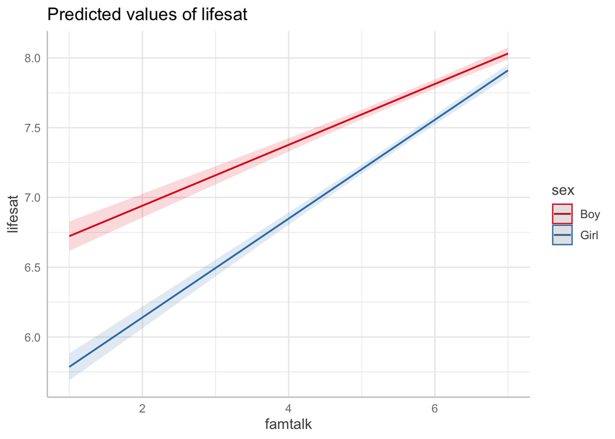

```r
theme_set(theme_sjplot())
plot_model(m2, type = "pred", terms = c("famtalk", "sex"))
```

We can see a higher slope for girls than for boys in predicting life satisfaction with ability to talk to family about the problems, which illustrates this 0.14 points interaction effect.

## 3. Model with a non-linear (polynomial) effect

Let’s add a polynomial effect to famhelp variable.

```r
m3 <- lm(lifesat ~ age + sex + poly(famhelp, 3) + famtalk, data = data)
tab_model(m3, title = "Model 3. Formula: lifesat ~ age + sex + poly(famhelp, 3) + famtalk.")
```

Model 3. Formula: lifesat ~ age + sex + poly(famhelp, 3) + famtalk.

|  | lifesat |  |  |
| --- | --- | --- | --- |
| Predictors | Estimates | CI | p |
| (Intercept) | 7.63 | 7.42 – 7.85 | **<0.001** |
| age | -0.11 | -0.13 – -0.10 | **<0.001** |
| sex [Girl] | -0.29 | -0.33 – -0.25 | **<0.001** |
| famhelp [1st degree] | 31.56 | 26.78 – 36.35 | **<0.001** |
| famhelp [2nd degree] | 52.13 | 48.65 – 55.61 | **<0.001** |
| famhelp [3rd degree] | -16.29 | -19.74 – -12.84 | **<0.001** |
| famtalk | 0.28 | 0.26 – 0.29 | **<0.001** |
| Observations | 24855 |  |  |
| R<sup>2</sup> / R<sup>2</sup> adjusted | 0.181 / 0.181 |  |  |

Proceeding to the predictors and effects explanation:

- with every rise by 1 point in age, level of life satisfaction falls by 0.11 points;
- Girls are less happy than boys by 0.29 points;
- with every rise by 1 point in estimating the family’s talking atmosphere, life satisfaction evaluation rises by 0.28 points.
- Life satisfactions grows with 1st and 2nd degrees of family help, but falls with the third one.

That’s how polynomial effect looks. We can see that level of life satisfaction drastically falls under the 3 points of family help, than goes quite plain to 4 points of family help, and then edgy grows to the following estimation of family help up to final 7.

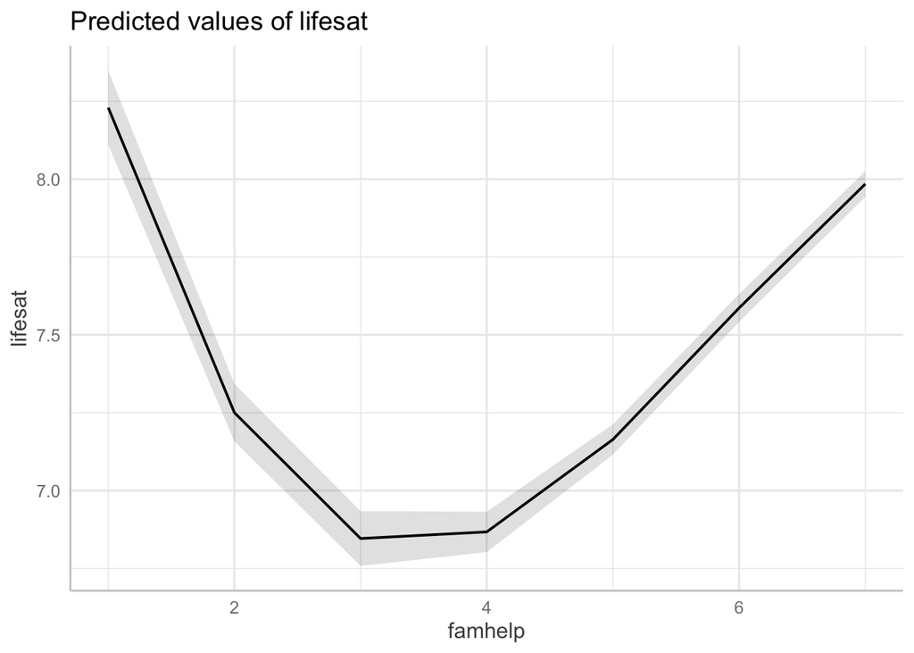

```r
plot_model(m3, type = "pred", terms = "famhelp")
```

# Choosing the best model

Let’s compare all 3 created models.

```r
tab_model(m1, m2, m3, title = "Comparing all three models.")
```

Comparing all three models.

|  | lifesat |  |  | lifesat |  |  | lifesat |  |  |
| --- | --- | --- | --- | --- | --- | --- | --- | --- | --- |
| Predictors | Estimates | CI | p | Estimates | CI | p | Estimates | CI | p |
| (Intercept) | 7.21 | 7.00 – 7.42 | **<0.001** | 7.59 | 7.37 – 7.81 | **<0.001** | 7.63 | 7.42 – 7.85 | **<0.001** |
| age | -0.13 | -0.15 – -0.12 | **<0.001** | -0.13 | -0.15 – -0.12 | **<0.001** | -0.11 | -0.13 – -0.10 | **<0.001** |
| sex [Girl] | -0.32 | -0.36 – -0.27 | **<0.001** | -1.07 | -1.22 – -0.93 | **<0.001** | -0.29 | -0.33 – -0.25 | **<0.001** |
| famhelp | 0.11 | 0.09 – 0.13 | **<0.001** | 0.11 | 0.09 – 0.13 | **<0.001** |  |  |  |
| famtalk | 0.29 | 0.27 – 0.31 | **<0.001** | 0.22 | 0.20 – 0.24 | **<0.001** | 0.28 | 0.26 – 0.29 | **<0.001** |
| famtalk * sex [Girl] |  |  |  | 0.14 | 0.11 – 0.16 | **<0.001** |  |  |  |
| famhelp [1st degree] |  |  |  |  |  |  | 31.56 | 26.78 – 36.35 | **<0.001** |
| famhelp [2nd degree] |  |  |  |  |  |  | 52.13 | 48.65 – 55.61 | **<0.001** |
| famhelp [3rd degree] |  |  |  |  |  |  | -16.29 | -19.74 – -12.84 | **<0.001** |
| Observations | 24855 |  |  | 24855 |  |  | 24855 |  |  |
| R<sup>2</sup> / R<sup>2</sup> adjusted | 0.150 / 0.150 |  |  | 0.154 / 0.154 |  |  | 0.181 / 0.181 |  |  |

Firstly, it is very good that in all of model we’ve got all the predictors to be strongly significant. So, leaving out this part, I’m choosing the best model by the R-squared indicator. Among the rest, higher R-squared = 0.181 belongs to the third model with the polymonial effect. Thus, this one is best and this one to be checked.

# Cheching the best model

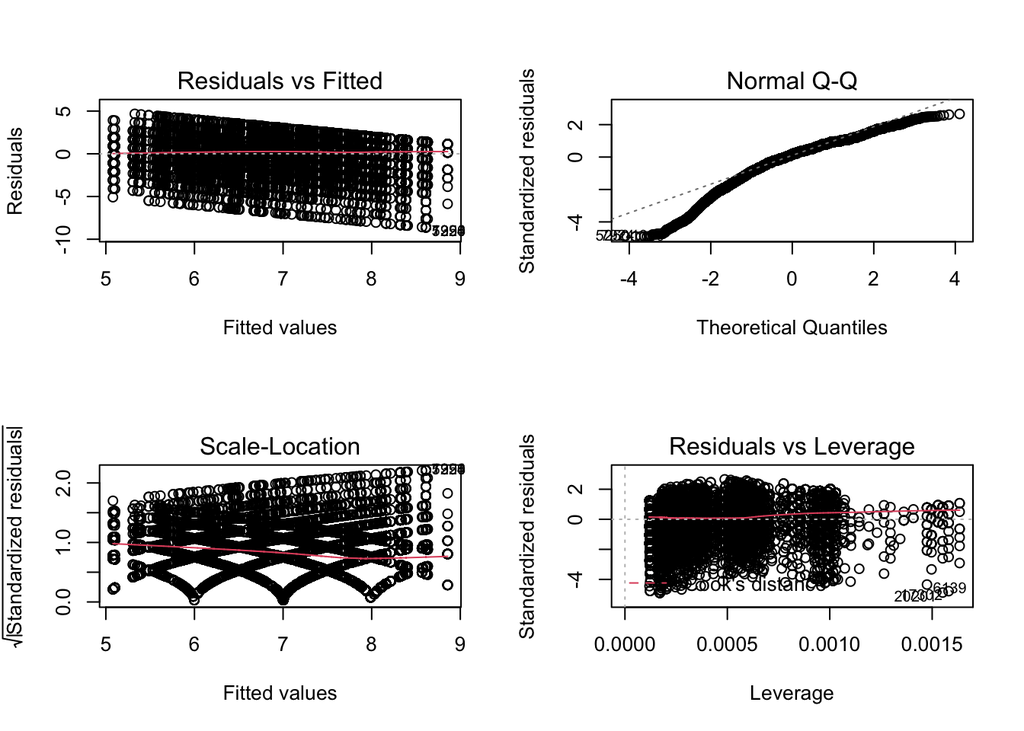

```r
par(mfrow=c(2,2))
plot(m3)
```

Here are conclusions that are made basing on the plots above:

- the line of residuals vs fitted allocation is straight all over it’s length, which indicates no problems with the model;
- the distribution of the residuals does not really have normal distribution, showing the absence smaller than required values on tails which may indicate a problem with the model;
- the line of scale vs location is smooth almost over all it’s length, however the points are not equally distributed, which is another problem with the model;
- none of the points cross the Cook’s distance, and the diagnostic line is almost smooth, so it is problematic, but only to a certain degree.

So, the main problems are detected in the distribution of the residuals and scale-location plot of them.